# Boxplots

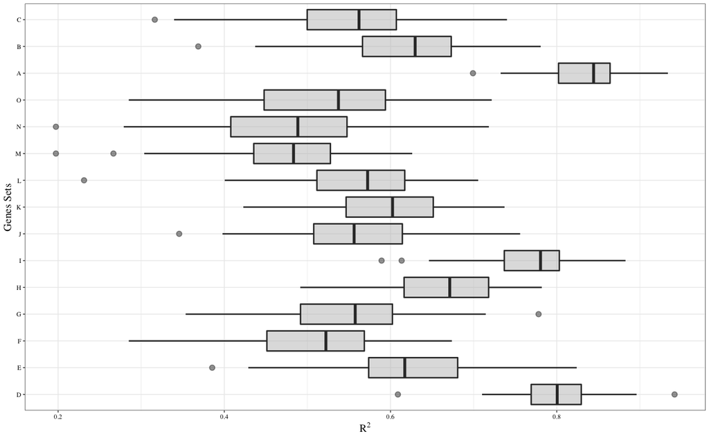

#TLDR: prefer to use personalized themes and just replace their elements like below

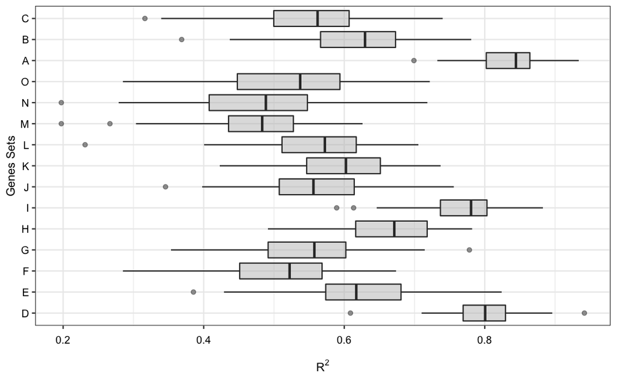

```r
#when we use theme () meaning pass anything in that we overrise current thme
# we can use it with other themes

personal_theme <- function() {
    font<-"Arial"
    theme_bw()%+replace%


  theme(

   #text elements
      plot.title = element_text(             #title
                   family = font,            #set font family
                   size = 20,                #set font size
                   face = 'bold',            #bold typeface
                   hjust = 0,                #left align
                   vjust = 2),               #raise slightly

      plot.subtitle = element_text(          #subtitle
                   family = font,            #font family
                   size = 14),               #font size

      plot.caption = element_text(           #caption
                   family = font,            #font family
                   size = 9,                 #font size
                   hjust = 1),               #right align

      axis.title = element_text(             #axis titles
                   family = font,            #font family
                   size = 10),               #font size

      axis.text = element_text(              #axis text
                   family = font,            #axis famuly
                   size = 9),                #font size

      axis.text.x = element_text(            #margin for axis text
                    margin=margin(5, b = 10))

      #since the legend often requires manual tweaking
      #based on plot content, don't define it here
    )

}







# Box plot
ggplot(df.QN.long, aes(x=Rsq, y=GenesSet))+
  geom_boxplot(fill="grey",  alpha=0.5)+                                        # boxplot fill color
  ylab("Genes Sets")+                                                                     # y-axis labels
  xlab (expression(paste("R"^"2")))+
  personal_theme()
```

### Titles Labels fonts and sizes

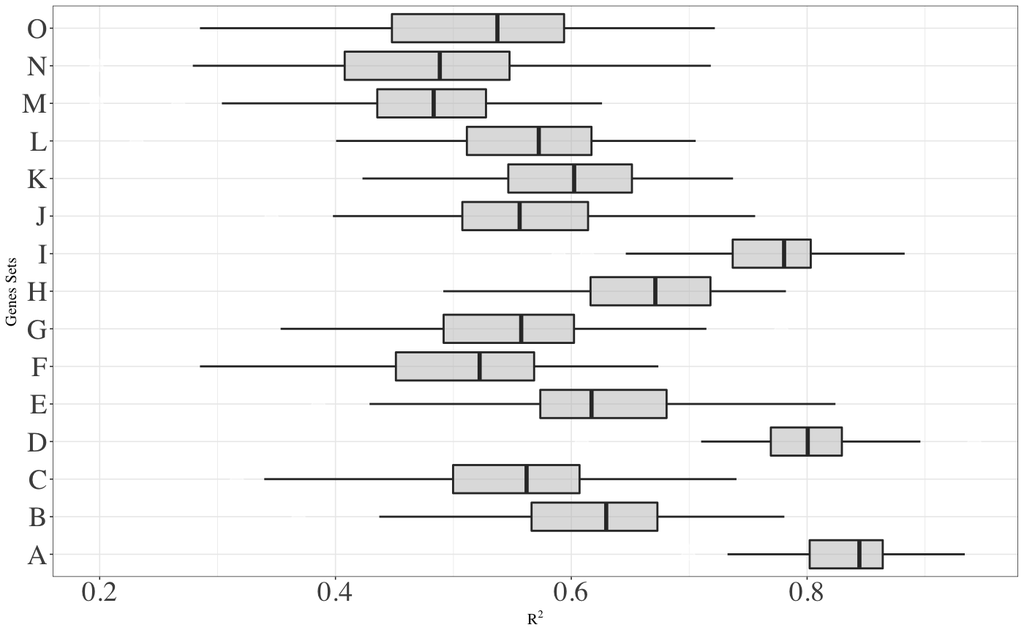

### Fonts families

We use theme() to tweak the display of an existing theme.

```r
theme_bw(base_size=12, base_family = "")
```

### Font realated things

TLDR:We need for mac to get the font we need to use in ggplot2

library(extrafont) font_import() fonts()

```r
#see hat fonts you have available with the command windowsFonts()
#windowsFonts()
fonts()#display present fonts
```

```
  [1] ".SF Compact Display"    ".SF Compact Rounded"    ".SF Compact Text"
  [4] ".Keyboard"              ".New York"              "System Font"
  [7] ".SF NS Mono"            ".SF NS Rounded"         "Andale Mono"
 [10] "Apple Braille"          "AppleMyungjo"           "Arial Black"
 [13] "Arial"                  "Arial Narrow"           "Arial Rounded MT Bold"
 [16] "Arial Unicode MS"       "Bodoni Ornaments"       "Bodoni 72 Smallcaps"
 [19] ""                       "Brush Script MT"        "Comic Sans MS"
 [22] "Courier New"            "DIN Alternate"          "DIN Condensed"
 [25] "Georgia"                "Impact"                 "Khmer Sangam MN"
 [28] "Lao Sangam MN"          "Luminari"               "Microsoft Sans Serif"
 [31] "Noto Sans Avestan"      "Noto Sans Bamum"        "Noto Sans Batak"
 [34] "Noto Sans Brahmi"       "Noto Sans Buginese"     "Noto Sans Buhid"
 [37] "Noto Sans Carian"       "Noto Sans Chakma"       "Noto Sans Cham"
 [40] "Noto Sans Coptic"       "Noto Sans Cuneiform"    "Noto Sans Cypriot"
 [43] "Noto Sans EgyptHiero"   "Noto Sans Glagolitic"   "Noto Sans Gothic"
```

[output cut: 19 more lines]

You can find the name of a font you need for the family parameter of element_text with the following code snippet:

```r
names(wf[wf=="Arial"])
```

[output not shown]

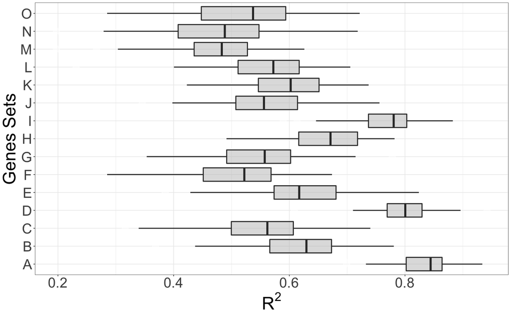

### problems related to Outlier

How to deal eith their visualisations couple of options discussed here

Option 1: use the color option to matcvh the outliers with background

```r
ggplot(df.QN.long, aes(x=Rsq, y=GenesSet))+
geom_boxplot(fill="grey",  alpha=0.5, #coef=1e30,
               outlier.colour = "white",
                 #outlier.shape = 24,
                 outlier.fill = "white",
                 #outlier.size = 3 # not actually needed
)
```

[output not shown]

second use the high limit then default 1.5 in coef option to do it.

Caveat is that it extends the whiskers and not rescale your plot.

It force the whiskers to extend to the max and min values, you can tweak the coef argument. Default value for coef is 1.5 (i.e. default length of the whiskers is 1.5 times the IQR).

[figure not shown]

#References For outlers related :https://stackoverflow.com/questions/5677885/ignore-outliers-in-ggplot2-boxplot Font of axis titles etc: https://statisticsglobe.com/increase-font-size-in-plot-in-r